#### ▶ 정당지지도

더불어민주당 44.0%, 국민의힘 36.9%, 정의당 2.3%, 기타 정당 2.2%, 지지하는 정당이 없다 13.8%, 잘 모르겠다 0.8%

#### ▶ 대통령 국정 수행 평가

잘하고 있다 39.3%, 잘못하고 있다 58.8%, 잘 모르겠다 1.9%

#### ☑ 현재 국내정치 수준 인식

과거 대비 좋아졌다 17.6%, 과거와 비슷한 수준이다 19.9%, 과거 대비 나빠졌다 57.5%, 잘 모르겠다 5.0%

#### ☑ 향후 국내정치 수준 전망

현재보다 나아질 것이다 30.4%, 현재와 비슷한 수준이 될 것이다 26.1%, 현재보다 나빠질 것이다 40.3%, 잘 모르겠다 3.1%

#### ☑ 과거 대비 현재 살림살이

과거 대비 좋아졌다 14.7%, 과거와 비슷한 수준이다 38.0%, 과거 대비 나빠졌다 44.9%, 잘 모르겠다 2.4%

#### ☑ 향후 가계 경제상황 전망

현재보다 나아질 것이다 25.8%, 현재와 비슷한 수준이 될 것이다 30.3%, 현재보다 나빠질 것이다 40.9%, 잘 모르겠다 3.0%

#### ☑ 현재 개인 행복감 인식

행복하지 않다 36.9%, 보통이다 35.1%, 행복하다 26.9%, 잘 모르겠다 1.2%

#### ☑ 향후 개인 행복감 전망

현재보다 나아질 것이다 31.7%, 현재와 비슷한 수준이 될 것이다 38.9%, 현재보다 나빠질 것이다 25.2%, 잘 모르겠다 4.1%

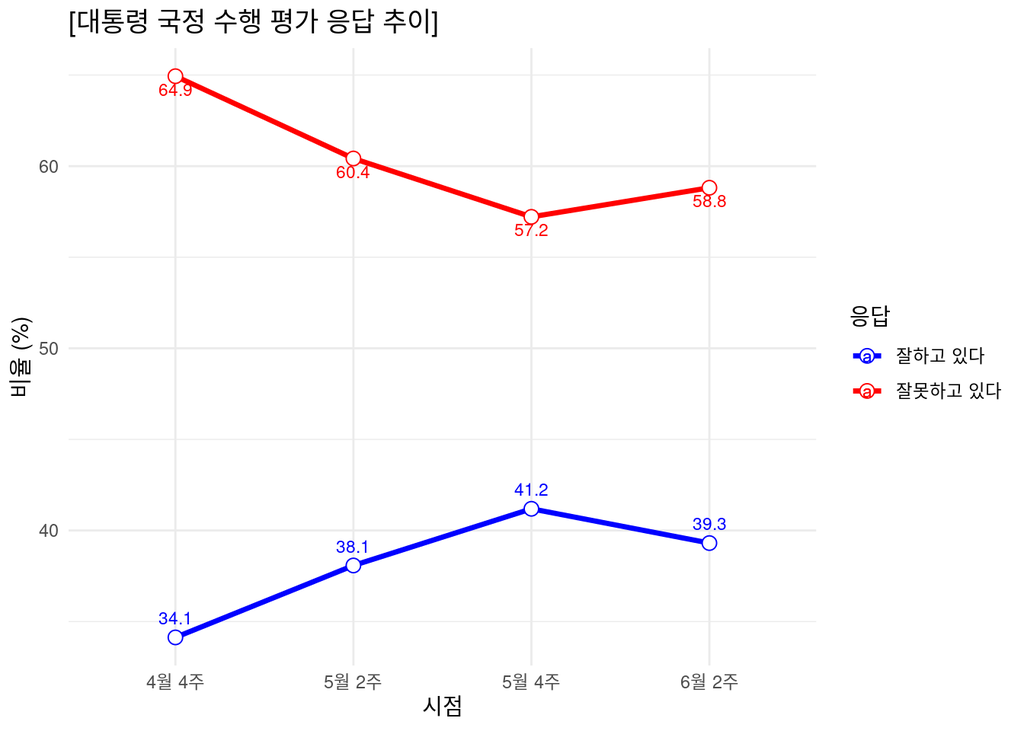

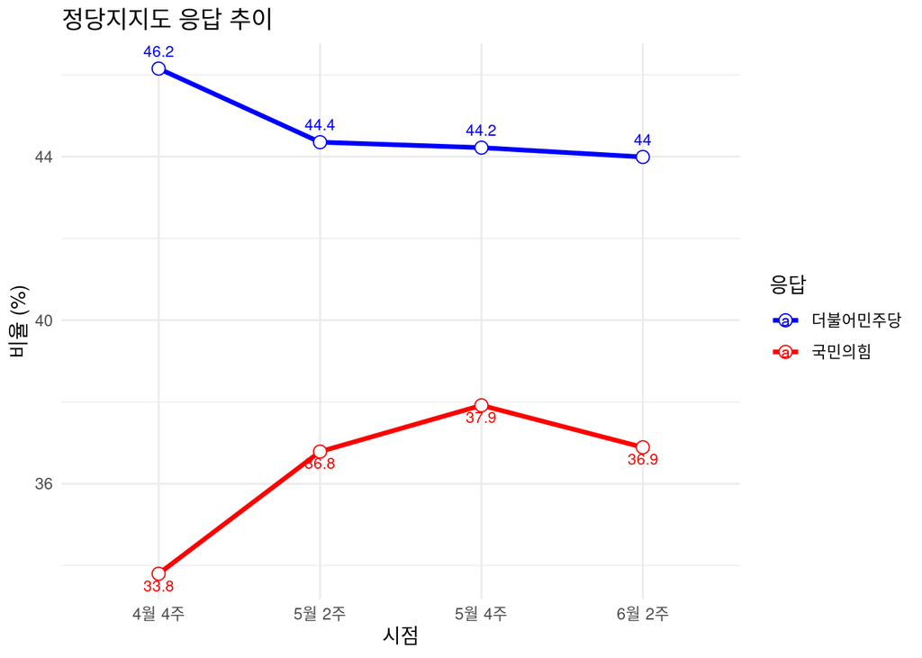

### 참고사항

- 표본수는 2,001명,표본오차는 95% ±2.2%p
- [중앙선거여론조사심의위원회](https://nesdc.go.kr/portal/bbs/B0000005/list.do?menuNo=200467)에서 관련사항 확인가능

2023.06.07 (수) 09:12 제작

- 연구개발 단계입니다.
- 순위별 최빈 단어 기준의 분류기법입니다.
- 제공: 감동과 마음의 [조원씨앤아이](http://jowoncni.com/html/index.html)